# Prediction of academic achievement in adolescents from teacher reports of inattention in childhood - a pattern classification study

```r
print(fit.Cpcla)
```

```
Model formula:
averBinned ~ gender + grade + snap1 + snap2 + snap3 + snap4 +
    snap5 + snap6 + snap7 + snap8 + snap9

Fitted party:
[1] root
|   [2] gender <= 0
|   |   [3] snap6 <= 1
|   |   |   [4] snap8 <= 1
|   |   |   |   [5] snap8 <= 0: L (n = 43, err = 46.5%)
|   |   |   |   [6] snap8 > 0
|   |   |   |   |   [7] grade <= 3: M (n = 561, err = 61.5%)
|   |   |   |   |   [8] grade > 3: H (n = 157, err = 55.4%)
|   |   |   [9] snap8 > 1: L (n = 253, err = 51.0%)
|   |   [10] snap6 > 1: L (n = 127, err = 37.0%)
|   [11] gender > 0
|   |   [12] snap2 <= 1
|   |   |   [13] snap6 <= 1: H (n = 1159, err = 58.1%)
|   |   |   [14] snap6 > 1: L (n = 27, err = 40.7%)
|   |   [15] snap2 > 1: L (n = 70, err = 35.7%)

Number of inner nodes:    7
Number of terminal nodes: 8
```

```r
#Table of prediction errors
table(predict(fit.Cpcla), D$averBinned)
```

```
      H   L   M
  H 556 319 441
  L  71 288 161
  M 173 172 216
```

```r
# Estimated class probabilities
tr.Cpred = predict(fit.Cpcla, newdata=C, type="prob")
print(head(tr.Cpred))
```

```
         H         L         M
1 0.419327 0.2338223 0.3468507
2 0.419327 0.2338223 0.3468507
3 0.419327 0.2338223 0.3468507
4 0.419327 0.2338223 0.3468507
5 0.419327 0.2338223 0.3468507
6 0.419327 0.2338223 0.3468507
```

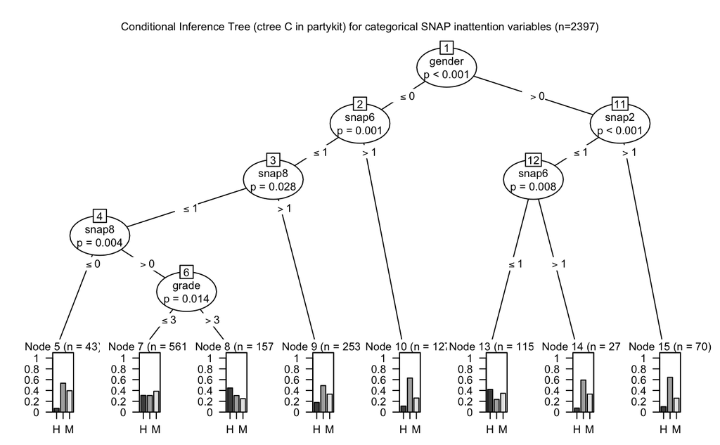

```r
plot(fit.Cpcla, gp = gpar(fontsize = 8),     # font size changed to 6, or 8
  inner_panel=node_inner,
  ip_args=list(
       abbreviate = FALSE,
       id = TRUE),
  main=txt
  )
```

```r
pdf("../manuscript/Figs/cart_partykit_ctree_C.pdf", width = 8, height = 5)
plot(fit.Cpcla, gp = gpar(fontsize = 8),     # font size changed to 6, or 8
  inner_panel=node_inner,
  ip_args=list(
       abbreviate = FALSE,
       id = TRUE),
  main=txt
  )
dev.off()
```

```r
library(partykit)
txt = sprintf("Conditional Inference Tree (ctree E in partykit) for categorical SNAP inattention variables (n=%d)", n)
E$averBinnedF = as.factor(E$averBinned)
E <- subset(E, select = -c(averBinned))
frmla = averBinnedF ~ gender + grade + snap1 + snap2 + snap3 +
    snap4 + snap5 + snap6 + snap7 + snap8 + snap9
fit.Epcla <- ctree(frmla, data=E)
class(fit.Epcla)  # different class from before
```

```
[1] "constparty" "party"
```

```r
print(fit.Epcla)
```

```
Model formula:
averBinnedF ~ gender + grade + snap1 + snap2 + snap3 + snap4 +
    snap5 + snap6 + snap7 + snap8 + snap9

Fitted party:
[1] root
|   [2] gender <= 0
|   |   [3] snap6 <= 1
|   |   |   [4] snap8 <= 1
|   |   |   |   [5] snap8 <= 0: 0 (n = 43, err = 46.5%)
|   |   |   |   [6] snap8 > 0
|   |   |   |   |   [7] grade <= 3: 1 (n = 561, err = 61.5%)
|   |   |   |   |   [8] grade > 3: 2 (n = 157, err = 55.4%)
|   |   |   [9] snap8 > 1: 0 (n = 253, err = 51.0%)
|   |   [10] snap6 > 1: 0 (n = 127, err = 37.0%)
|   [11] gender > 0
|   |   [12] snap2 <= 1
|   |   |   [13] snap6 <= 1: 2 (n = 1159, err = 58.1%)
|   |   |   [14] snap6 > 1: 0 (n = 27, err = 40.7%)
|   |   [15] snap2 > 1: 0 (n = 70, err = 35.7%)

Number of inner nodes:    7
Number of terminal nodes: 8
```

```r
#Table of prediction errors
table(predict(fit.Epcla), E$averBinnedF)
```

```
      0   1   2
  0 288 161  71
  1 172 216 173
  2 319 441 556
```

```r
# Estimated class probabilities
tr.Epred = predict(fit.Epcla, newdata=E, type="prob")
print(head(tr.Epred))
```

```
          0         1        2
1 0.2338223 0.3468507 0.419327
2 0.2338223 0.3468507 0.419327
3 0.2338223 0.3468507 0.419327
4 0.2338223 0.3468507 0.419327
5 0.2338223 0.3468507 0.419327
6 0.2338223 0.3468507 0.419327
```

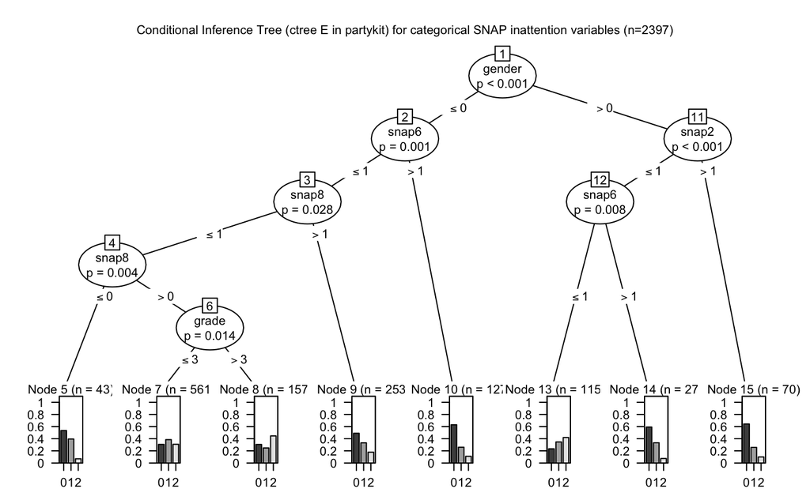

```r
plot(fit.Epcla, gp = gpar(fontsize = 8),     # font size changed to 6, or 8
  inner_panel=node_inner,
  ip_args=list(
       abbreviate = FALSE,
       id = TRUE),
  main=txt
  )
```

```r
pdf("../manuscript/Figs/cart_partykit_ctree_E.pdf", width = 8, height = 5)
plot(fit.Epcla, gp = gpar(fontsize = 8),     # font size changed to 6, or 8
  inner_panel=node_inner,
  ip_args=list(
       abbreviate = FALSE,
       id = TRUE),
  main=txt
  )
dev.off()
```

#### rpart:

This package includes several example sets of data that can be used for recursive partitioning and regression trees. Categorical or continuous variables can be used depending on whether one wants classification trees or regression trees. This package as well at the tree package are probably the two go-to packages for trees. However, care should be taken as the tree package and the rpart package can produce very different results.

```r
library(rpart)
frmla = averBinned ~ gender + grade + snap1 + snap2 + snap3 +
    snap4 + snap5 + snap6 + snap7 + snap8 + snap9
fit = rpart(frmla, method="class", data=D)
printcp(fit) # display the results
```

```
Classification tree:
rpart(formula = frmla, data = D, method = "class")

Variables actually used in tree construction:
[1] gender grade  snap2  snap8

Root node error: 1579/2397 = 0.65874

n= 2397

        CP nsplit rel error  xerror     xstd
1 0.087397      0   1.00000 1.01203 0.014617
2 0.036732      1   0.91260 0.93857 0.015063
3 0.015833      2   0.87587 0.89740 0.015243
4 0.010000      4   0.84421 0.87144 0.015332
```

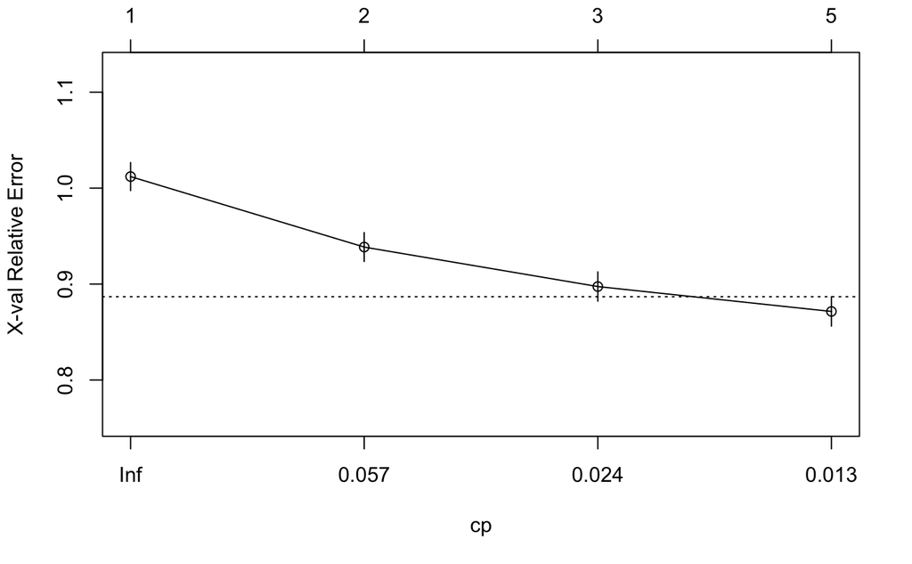

```r
plotcp(fit) # visualize cross-validation results
```

```r
summary(fit) # detailed summary of splits
```

```
Call:
rpart(formula = frmla, data = D, method = "class")
  n= 2397

          CP nsplit rel error    xerror       xstd
1 0.08739709      0 1.0000000 1.0120329 0.01461658
2 0.03673211      1 0.9126029 0.9385687 0.01506324
3 0.01583281      2 0.8758708 0.8974034 0.01524340
4 0.01000000      4 0.8442052 0.8714376 0.01533225

Variable importance
 snap2  snap8  snap5  snap4  snap6  snap7 gender  grade
    36     17     13     11      8      6      4      3

Node number 1: 2397 observations,    complexity param=0.08739709
  predicted class=M  expected loss=0.6587401  P(node) =1
    class counts:   800   779   818
   probabilities: 0.334 0.325 0.341
  left son=2 (2117 obs) right son=3 (280 obs)
  Primary splits:
      snap2 splits as  RRL, improve=54.12938, (0 missing)
      snap8 splits as  RRL, improve=48.88998, (0 missing)
      snap6 splits as  RRL, improve=35.94910, (0 missing)
      snap1 splits as  RRL, improve=28.69533, (0 missing)
      snap5 splits as  RRL, improve=26.77001, (0 missing)
  Surrogate splits:
      snap5 splits as  RRL, agree=0.924, adj=0.354, (0 split)
      snap4 splits as  RRL, agree=0.918, adj=0.300, (0 split)
      snap8 splits as  LRL, agree=0.912, adj=0.246, (0 split)
      snap6 splits as  RRL, agree=0.909, adj=0.221, (0 split)
      snap7 splits as  RRL, agree=0.904, adj=0.175, (0 split)

Node number 2: 2117 observations,    complexity param=0.03673211
  predicted class=H  expected loss=0.6343883  P(node) =0.8831873
    class counts:   774   597   746
   probabilities: 0.366 0.282 0.352
  left son=4 (1777 obs) right son=5 (340 obs)
  Primary splits:
      snap8  splits as  RRL, improve=13.086690, (0 missing)
      gender splits as  LR,  improve=10.798920, (0 missing)
```

[output cut: 52 more lines]

```
      snap9 splits as  RRL, improve=0.9882676, (0 missing)
      snap3 splits as  R-L, improve=0.2594907, (0 missing)
  Surrogate splits:
      snap7 splits as  L-R, agree=0.780, adj=0.012, (0 split)
      snap1 splits as  RLR, agree=0.778, adj=0.006, (0 split)

Node number 18: 162 observations
  predicted class=H  expected loss=0.5555556  P(node) =0.06758448
    class counts:    72    49    41
   probabilities: 0.444 0.302 0.253

Node number 19: 564 observations
  predicted class=M  expected loss=0.606383  P(node) =0.2352941
    class counts:   172   170   222
   probabilities: 0.305 0.301 0.394
```

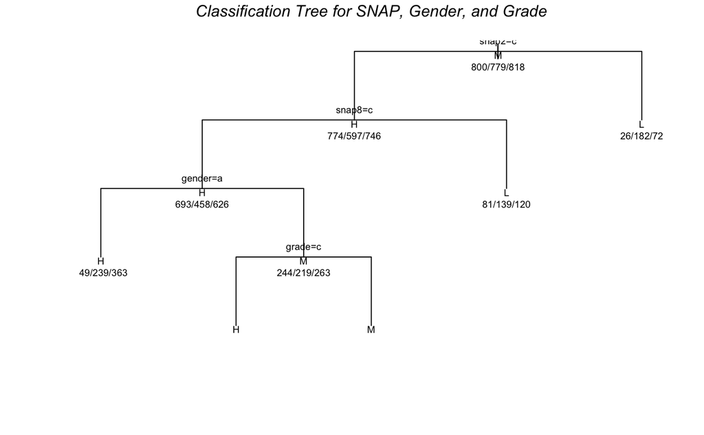

```r
# plot tree
plot(fit, uniform=TRUE,
     main=list("Classification Tree for SNAP, Gender, and Grade\n",
               cex = 1.0, col = "black", font = 3))
text(fit, use.n=TRUE, all=TRUE, cex=.6)
```

```r
# tabulate some of the data
table(subset(D, grade=='3rd')$averBinned)
```

```
  H   L   M
251 263 313
```

#### tree:

This is the primary R package for classification and regression trees. It has functions to prune the tree as well as general plotting functions and the mis-classifications (total loss). The output from tree can be easier to compare to the General Linear Model (GLM) and General Additive Model (GAM) alternatives.

```r
library(tree)
tr = tree(averBinned ~ ., data=D)
summary(tr)
```

```
Classification tree:
tree(formula = averBinned ~ ., data = D)
Variables actually used in tree construction:
[1] "snap2"
Number of terminal nodes:  2
Residual mean deviance:  2.13 = 5101 / 2395
Misclassification error rate: 0.6012 = 1441 / 2397
```

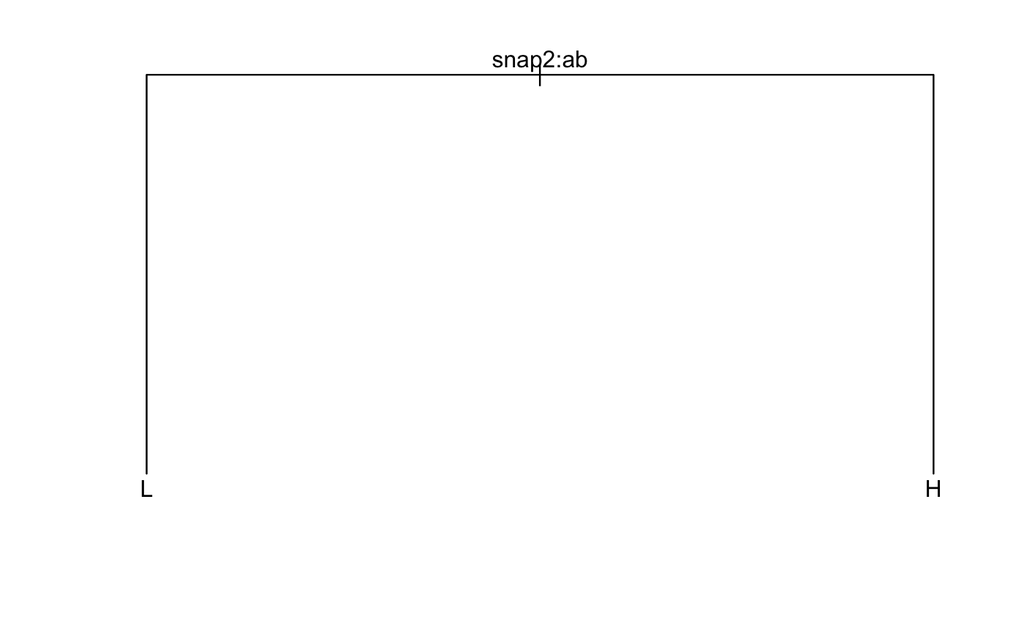

```r
plot(tr)
text(tr)
```

#### maptree:

Graph a classification or regression tree with a hierarchical tree diagram, optionally including colored symbols at leaves and additional info at intermediate nodes.

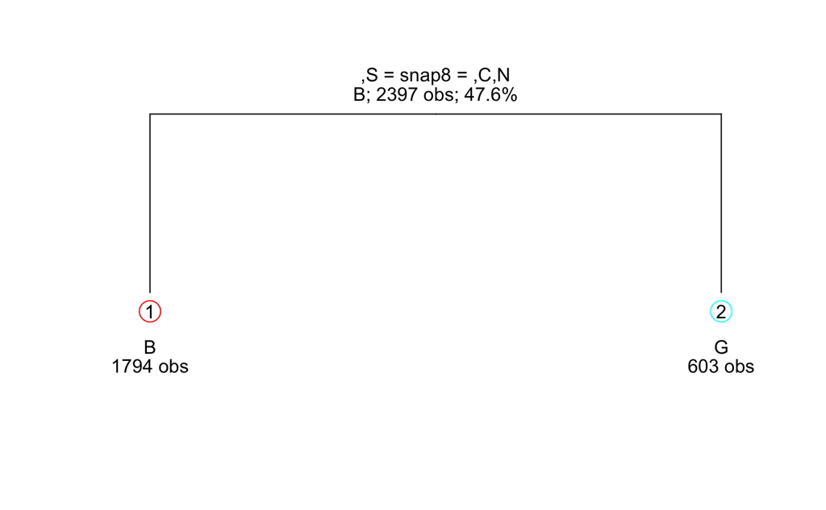

```r
library(maptree)
library(cluster)
library(rpart)
draw.tree(clip.rpart(rpart(D), best=7), nodeinfo=TRUE, units="",cases="obs", digits=0)
```

### Cross-validating a CART model

#### Using the ‘cvTools’ package

http://stackoverflow.com/questions/16717970/cross-validating-a-cart-model

```r
library(rpart)
library(cvTools)
library(psych)

# Read and check the data
C <- read.csv(file = "../data/inattention_nomiss_2397x12_snap_is_0_1_2_outcome_is_L_M_H.csv")
str(C)
headTail(C)

# Estimate the prediction error of a model via (repeated) K-fold cross-validation.
# It is thereby possible to supply an object returned by a model fitting function,
# a model fitting function itself, or an unevaluated function call to a model fitting function.

cvFit(rpart, formula=averBinned ~ ., data=C,
             cost=function(y, yHat) (y != yHat) + 0,  K = 5, R = 10, predictArgs=c(type='class'))

#            cost=function(y, yHat) (y != yHat) + 0, predictArgs=c(type='class'))
```

[output not shown]

#### A Multi-Class Summary Function

https://github.com/rseiter/PracticalMLProject/blob/master/multiClassSummary.R https://github.com/topepo/caret/issues/107 topepo added a commit that referenced this issue on Sep 8, 2015:

```r
# Multi-Class Summary Function
# Based on caret:::twoClassSummary
# From: http://moderntoolmaking.blogspot.com/2012/07/error-metrics-for-multi-class-problems.html
multiClassSummary <- function (data, lev = NULL, model = NULL){
  #Check data
  if (!all(levels(data[, "pred"]) == levels(data[, "obs"])))
    stop("levels of observed and predicted data do not match")
  ## Overall multinomial loss
  lloss <- mnLogLoss(data = data, lev = lev, model = model)
  #Calculate custom one-vs-all ROC curves for each class
  prob_stats <- lapply(levels(data[, "pred"]),
                       function(class){
                         #Grab one-vs-all data for the class
                         pred <- ifelse(data[, "pred"] == class, 1, 0)
                         obs  <- ifelse(data[,  "obs"] == class, 1, 0)
                         prob <- data[,class]
                         #Calculate one-vs-all AUC
                         prob_stats <- as.vector(auc(obs, prob))
                         names(prob_stats) <- c('ROC')
                         return(prob_stats)
                       })
  roc_stats <- mean(unlist(prob_stats))
  #Calculate confusion matrix-based statistics
  CM <- confusionMatrix(data[, "pred"], data[, "obs"])
  #Aggregate and average class-wise stats
  #Todo: add weights
  # RES: support two classes here as well
  #browser() # Debug
  if (length(levels(data[, "pred"])) == 2) {
    class_stats <- c(CM$byClass, roc_vals)
  } else {
    class_stats <- colMeans(CM$byClass)
    names(class_stats) <- paste("Mean", names(class_stats))
  }
  # Aggregate overall stats
  overall_stats <- c(CM$overall, lloss, Mean_ROC = roc_stats)
  # Combine overall with class-wise stats and remove some stats we don't want
  stats <- c(overall_stats, class_stats)
  stats <- stats[! names(stats) %in% c('AccuracyNull', "AccuracyLower", "AccuracyUpper",
                                       "AccuracyPValue", "McnemarPValue",
                                       'Mean Prevalence', 'Mean Detection Prevalence')]
  # Clean names
  names(stats) <- gsub('[[:blank:]]+', '_', names(stats))
  if (length(levels(data[, "pred"]) == 2)) {
    # Change name ordering to place most useful first
    # May want to remove some of these eventually
    stats <- stats[c("logLoss", "Mean_ROC",
                     "Mean_Sensitivity", "Mean_Specificity", "Accuracy", "Kappa",
                     "Mean_Pos_Pred_Value", "Mean_Neg_Pred_Value", "Mean_Detection_Rate",
                     "Mean_Balanced_Accuracy")]
  }
  return(stats)
}
#})
# RES: compare with
# defaultSummary
# function (data, lev = NULL, model = NULL)
# {
#   if (is.character(data$obs))
#     data$obs <- factor(data$obs, levels = lev)
#   postResample(data[, "pred"], data[, "obs"])
# }
# <environment: namespace:caret>

# twoClassSummary
# function (data, lev = NULL, model = NULL)
# {
#   require(pROC)
#   if (!all(levels(data[, "pred"]) == levels(data[, "obs"])))
#     stop("levels of observed and predicted data do not match")
#   rocObject <- try(pROC::roc(data$obs, data[, lev[1]]), silent = TRUE)
#   rocAUC <- if (class(rocObject)[1] == "try-error")
#     NA
#   else rocObject$auc
#   out <- c(rocAUC, sensitivity(data[, "pred"], data[, "obs"],
#                                lev[1]), specificity(data[, "pred"], data[, "obs"], lev[2]))
#   names(out) <- c("ROC", "Sens", "Spec")
#   out
# }
# <environment: namespace:caret>
```

```r
# Testing multiClassSummary()

library(AppliedPredictiveModeling)
data(schedulingData)

set.seed(1417)
in_train <- createDataPartition(schedulingData$Class, p = 3/4, list = FALSE)

training <- schedulingData[ in_train,]
testing  <- schedulingData[-in_train,]

mod <- train(Class ~ ., data = training, method = "rpart",
             tuneLength = 10,
             trControl = trainControl(classProbs = TRUE,
                                      summaryFunction = multiClassSummary))

test_pred <- predict(mod, testing, type = "prob")
test_pred$obs <- testing$Class
test_pred$pred <- predict(mod, testing)

multiClassSummary(test_pred, lev = levels(test_pred$obs))
```

[output not shown]

#### Using the ‘caret’ package

CART: method = ‘rpart’ or Ordinal Responses: method = ‘rpartScore’ with a tuning parameter cp (Complexity Parameter). A model-specific variable importance metric is available.

```r
library(rpart)
library(caret)
library(psych)

# Read and check the data
C <- read.csv(file = "../data/inattention_nomiss_2397x12_snap_is_0_1_2_outcome_is_L_M_H.csv")
str(C)
headTail(C)

# number controls with the number of folds in K-fold cross-validation ("cv")
# tc <- trainControl(method = "cv", number = 10, classProbs = TRUE, summaryFunction = multiClassSummary)
tc <- trainControl(method = "cv", number = 10, savePredictions = TRUE)
rpart.grid <- expand.grid(.cp = c(0.2, 0.4))

# train.rpart <- train(averBinned ~., data = C, method = "rpart", trControl = tc, tuneGrid = rpart.grid, metric = "ROC")

train.rpart <- train(averBinned ~., data = C, method = "rpart", trControl = tc, tuneGrid = rpart.grid)
print(train.rpart)
```

[output not shown]

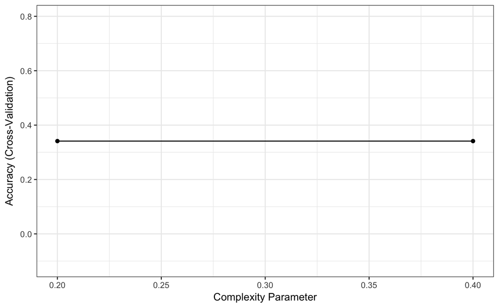

```r
# plot(train.rpart)
ggplot(train.rpart) + theme_bw()
```

### mlr: Machine Learning in R

https://www.rdocumentation.org/packages/mlr/versions/2.9?

```r
# http://stackoverflow.com/questions/36802846/how-to-tune-multiple-parameters-using-caret-package
# http://mlr-org.github.io/mlr-tutorial/release/html/measures/index.html
library(mlr)
library(psych)
# Read and check the data
C <- read.csv(file = "../data/inattention_nomiss_2397x12_snap_is_0_1_2_outcome_is_L_M_H.csv")
str(C)
```

```
'data.frame':   2397 obs. of  12 variables:
 $ gender    : int  1 1 1 1 1 1 1 1 1 1 ...
 $ grade     : int  2 2 2 2 2 2 2 2 2 2 ...
 $ snap1     : int  1 1 1 1 1 1 1 1 1 1 ...
 $ snap2     : int  1 1 1 1 1 1 1 1 1 1 ...
 $ snap3     : int  1 2 1 1 1 1 1 1 1 1 ...
 $ snap4     : int  1 1 1 1 1 1 1 1 1 1 ...
 $ snap5     : int  1 1 1 1 1 1 1 1 1 1 ...
 $ snap6     : int  1 1 1 1 1 1 1 1 1 1 ...
 $ snap7     : int  1 1 1 1 1 1 1 1 1 1 ...
 $ snap8     : int  1 1 1 1 1 1 1 1 2 1 ...
 $ snap9     : int  1 1 1 1 1 1 1 1 1 1 ...
 $ averBinned: Factor w/ 3 levels "H","L","M": 1 2 3 3 3 3 2 3 1 3 ...
```

```r
headTail(C)
```

|  | gender | grade | snap1 | snap2 | snap3 | snap4 | snap5 | snap6 | snap7 | snap8 | snap9 | averBinned |
| --- | --- | --- | --- | --- | --- | --- | --- | --- | --- | --- | --- | --- |
| 1 | 1 | 2 | 1 | 1 | 1 | 1 | 1 | 1 | 1 | 1 | 1 | H |
| 2 | 1 | 2 | 1 | 1 | 2 | 1 | 1 | 1 | 1 | 1 | 1 | L |
| 3 | 1 | 2 | 1 | 1 | 1 | 1 | 1 | 1 | 1 | 1 | 1 | M |
| 4 | 1 | 2 | 1 | 1 | 1 | 1 | 1 | 1 | 1 | 1 | 1 | M |
| ... | ... | ... | ... | ... | ... | ... | ... | ... | ... | ... | ... | NA |
| 2394 | 0 | 4 | 2 | 2 | 2 | 2 | 1 | 2 | 1 | 2 | 1 | M |
| 2395 | 0 | 4 | 2 | 1 | 1 | 1 | 1 | 1 | 1 | 1 | 1 | M |
| 2396 | 0 | 4 | 2 | 2 | 1 | 1 | 1 | 1 | 2 | 2 | 2 | M |
| 2397 | 0 | 4 | 2 | 1 | 1 | 1 | 1 | 1 | 1 | 1 | 1 | L |

```r
# Create a classification, regression, survival, cluster, cost-sensitive classification or multilabel task
# https://rdrr.io/cran/mlr/man/Task.html
# id - Id string for object. Default is the name of the R variable passed to data.
# data - A data frame containing the features and target variable(s).
# target - Name(s) of the target variable(s).
rpart.task = classif.task = makeClassifTask(id = "inattention", data = C, target = "averBinned")
# Create a description object for a resampling strategy
# https://rdrr.io/cran/mlr/man/makeResampleDesc.html
# method - “CV” for cross-validation, “LOO” for leave-one-out, “RepCV” for repeated cross-validation,
# “Bootstrap” for out-of-bag bootstrap, “Subsample” for subsampling, “Holdout” for holdout.
# predict -  What to predict during resampling: “train”, “test” or “both” sets. Default is “test”.
# iters - Number of iterations, for “CV”, “Subsample” and “Boostrap”.
# reps - Repeats for “RepCV”. Here iters = folds * reps. Default is 10.
# folds - Folds in the repeated CV for RepCV. Here iters = folds * reps. Default is 10.
# stratify - Should stratification be done for the target variable? For classification tasks,
#   this means that the resampling strategy is applied to all classes individually and the resulting
#   index sets are joined to make sure that the proportion of observations in each training
#   set is as in the original data set. Useful for imbalanced class sizes.
# We will use 10-fold cross-validation with 10 repetitions to assess the quality of a
# specific parameter setting.
resamp = makeResampleDesc("RepCV", predic = "test", folds = 10, reps = 10, stratify = TRUE)
# Create learner object
# https://rdrr.io/cran/mlr/man/makeLearner.html
# cl - Class of learner. By convention, all classification learners start with “classif.”,
#   all regression learners with “regr.”, all survival learners start with “surv.”,
#   all clustering learners with “cluster.”, and all multilabel classification learners start with
#   “multilabel.”. A list of all integrated learners is available on the learners help page.
# predict.type - Classification: “response” (= labels) or “prob” (= probabilities and labels by
#   selecting the ones with maximal probability). Regression: “response” (= mean response) or
#   “se” (= standard errors and mean response). Survival: “response” (= some sort of orderable risk)
#   or “prob” (= time dependent probabilities). Clustering: “response” (= cluster IDS) or
#   “prob” (= fuzzy cluster membership probabilities), Multilabel: “response” (= logical matrix
#   indicating the predicted class labels) or “prob” (= probabilities and corresponding
#   logical matrix indicating class labels). Default is “response”.
lrn = makeLearner("classif.rpart", predict.type = "response" )
# Get a description of all possible parameter settings for a learner.
# https://rdrr.io/cran/mlr/man/getParamSet.html
# https://mlr-org.github.io/mlr-tutorial/release/html/learner/index.html
# You can also check all the tunable params. The Learner object is a list and the following
# elements contain information regarding the hyperparameters and the type of prediction.
getParamSet(lrn)
```

```
                   Type len  Def   Constr Req Tunable Trafo
minsplit        integer   -   20 1 to Inf   -    TRUE     -
minbucket       integer   -    - 1 to Inf   -    TRUE     -
cp              numeric   - 0.01   0 to 1   -    TRUE     -
maxcompete      integer   -    4 0 to Inf   -    TRUE     -
maxsurrogate    integer   -    5 0 to Inf   -    TRUE     -
usesurrogate   discrete   -    2    0,1,2   -    TRUE     -
surrogatestyle discrete   -    0      0,1   -    TRUE     -
maxdepth        integer   -   30  1 to 30   -    TRUE     -
xval            integer   -   10 0 to Inf   -   FALSE     -
parms           untyped   -    -        -   -    TRUE     -
```

```r
# Nested Resampling
# https://mlr-org.github.io/mlr-tutorial/release/html/nested_resampling/index.html
makeFilterWrapper(lrn)
```

```
Learner classif.rpart.filtered from package randomForestSRC,rpart
Type: classif
Name: ; Short name:
Class: FilterWrapper
Properties: numerics,factors,ordered,missings,weights,prob,twoclass,multiclass
Predict-Type: response
Hyperparameters: xval=0,fw.method=rf.importance
```

```r
# Training a Learner
# Training a learner means fitting a model to a given data set.
# In mlr this can be done by calling function train on a Learner and a suitable Task.
# Training a learner works the same way for every type of learning problem.
# Function train returns an object of class WrappedModel, which encapsulates the fitted model,
# i.e., the output of the underlying R learning method.
# Additionally, it contains some information about the Learner, the Task, the features and
# observations used for training, and the training time.
# A WrappedModel can subsequently be used to make a prediction for new observations.
mod = train(lrn, rpart.task)
## Peak into mod
names(mod)
```

```
[1] "learner"       "learner.model" "task.desc"     "subset"        "features"      "factor.levels"
[7] "time"
```

```r
mod$learner
```

```
Learner classif.rpart from package rpart
Type: classif
Name: Decision Tree; Short name: rpart
Class: classif.rpart
Properties: twoclass,multiclass,missings,numerics,factors,ordered,prob,weights
Predict-Type: response
Hyperparameters: xval=0
```

```r
# Extract the fitted model ( mod$learner.model)
getLearnerModel(mod)
```

```
n= 2397

node), split, n, loss, yval, (yprob)
      * denotes terminal node

 1) root 2397 1579 M (0.3337505 0.3249896 0.3412599)
   2) snap2< 1.5 2167 1390 H (0.3585602 0.2921089 0.3493309)
     4) snap2>=0.5 2117 1343 H (0.3656117 0.2820028 0.3523855)
       8) snap8< 1.5 1789 1095 H (0.3879262 0.2588038 0.3532700)
        16) gender>=0.5 1053  604 H (0.4264008 0.2279202 0.3456790) *
        17) gender< 0.5 736  468 M (0.3328804 0.3029891 0.3641304)
          34) grade>=3.5 164   91 H (0.4451220 0.3048780 0.2500000) *
          35) grade< 3.5 572  345 M (0.3006993 0.3024476 0.3968531) *
       9) snap8>=1.5 328  194 L (0.2439024 0.4085366 0.3475610) *
     5) snap2< 0.5 50   14 L (0.0600000 0.7200000 0.2200000) *
   3) snap2>=1.5 230   84 L (0.1000000 0.6347826 0.2652174) *
```

[figure not shown]

```r
# Plot the fitted model
plot(getLearnerModel(mod))
```

```r
pred = predict(mod, newdata = C)
head(as.data.frame(pred))
```

|  | truth | response |
| --- | --- | --- |
| 1 | H | H |
| 2 | L | H |
| 3 | M | H |
| 4 | M | H |
| 5 | M | H |
| 6 | M | H |

```r
# In order to get predicted posterior probabilities we have to create a Learner
# with the appropriate predict.type.
lrn_prob = makeLearner("classif.rpart", predict.type = "prob")
mod_prob = train(lrn_prob, rpart.task)
pred_prob = predict(mod_prob, newdata = C)
head(as.data.frame(pred_prob))
```

|  | truth | prob.H | prob.L | prob.M | response |
| --- | --- | --- | --- | --- | --- |
| 1 | H | 0.4264008 | 0.2279202 | 0.345679 | H |
| 2 | L | 0.4264008 | 0.2279202 | 0.345679 | H |
| 3 | M | 0.4264008 | 0.2279202 | 0.345679 | H |
| 4 | M | 0.4264008 | 0.2279202 | 0.345679 | H |
| 5 | M | 0.4264008 | 0.2279202 | 0.345679 | H |
| 6 | M | 0.4264008 | 0.2279202 | 0.345679 | H |

```r
# In addition to the probabilities, class labels are predicted by choosing the class with
# the maximum probability and breaking ties at random.
# The predicted posterior probabilities can be accessed via the getPredictionProbabilities function.
head(getPredictionProbabilities(pred_prob))
```

|  | H | L | M |
| --- | --- | --- | --- |
| 1 | 0.4264008 | 0.2279202 | 0.345679 |
| 2 | 0.4264008 | 0.2279202 | 0.345679 |
| 3 | 0.4264008 | 0.2279202 | 0.345679 |
| 4 | 0.4264008 | 0.2279202 | 0.345679 |
| 5 | 0.4264008 | 0.2279202 | 0.345679 |
| 6 | 0.4264008 | 0.2279202 | 0.345679 |

```r
# Confusion matrix
# https://www.rdocumentation.org/packages/mlr/versions/2.9/topics/getConfMatrix
# Calculates confusion matrix for (possibly resampled) prediction.
# Rows indicate true classes, columns predicted classes. The marginal elements count the
# number of classification errors for the respective row or column, i.e., the number of
# errors when you condition on the corresponding true (rows) or predicted (columns) class.
# The last element in the margin diagonal displays the total amount of errors.
# Note that for resampling no further aggregation is currently performed.
# All predictions on all test sets are joined to a vector yhat, as are all labels
# joined to a vector y. Then yhat is simply tabulated vs y, as if both were computed
# on a single test set. This probably mainly makes sense when cross-validation is used for resampling.
print(getConfMatrix(pred, relative = FALSE))
```

```
       predicted
true      H   L   M -SUM-
  H     522 106 172   278
  L     290 316 173   463
  M     405 186 227   591
  -SUM- 695 292 345  1332
```

```r
print(getConfMatrix(pred, relative = TRUE))
```

```
       predicted
true            H         L         M     -SUM-
  H     0.6525000 0.1325000 0.2150000 0.3475000
  L     0.3722721 0.4056483 0.2220796 0.5943517
  M     0.4951100 0.2273839 0.2775061 0.7224939
  -SUM- 0.5217718 0.2192192 0.2590090 0.5556946
```

```r
# Feature Selection
# Often, data sets include a large number of features. The technique of extracting a subset of
# relevant features is called feature selection. Feature selection can enhance the
# interpretability of the model, speed up the learning process and improve the learner performance.
# There exist different approaches to identify the relevant features. mlr supports filter
# and wrapper methods.
# Calculates feature filter values.
# https://rdrr.io/cran/mlr/man/generateFilterValuesData.html
# Calculates numerical filter values for features. For a list of features, use listFilterMethods.
# fv = generateFilterValuesData(rpart.task, method = "cforest.importance")
fv = generateFilterValuesData(rpart.task, method = "rf.importance")
print(fv)
```

```
FilterValues:
Task: inattention
    name    type rf.importance
1 gender integer   0.017498272
2  grade integer   0.012028773
3  snap1 integer   0.001325530
4  snap2 integer   0.012511360
5  snap3 integer   0.003078202
6  snap4 integer   0.003279868
```

```r
print(fv$data)
```

| name | type | rf.importance |
| --- | --- | --- |
| gender | integer | 0.0174982715 |
| grade | integer | 0.0120287728 |
| snap1 | integer | 0.0013255304 |
| snap2 | integer | 0.0125113596 |
| snap3 | integer | 0.0030782015 |
| snap4 | integer | 0.0032798683 |
| snap5 | integer | 0.0053718573 |
| snap6 | integer | 0.0043071035 |
| snap7 | integer | 0.0002812817 |
| snap8 | integer | 0.0075935999 |

[output cut: 1 more lines]

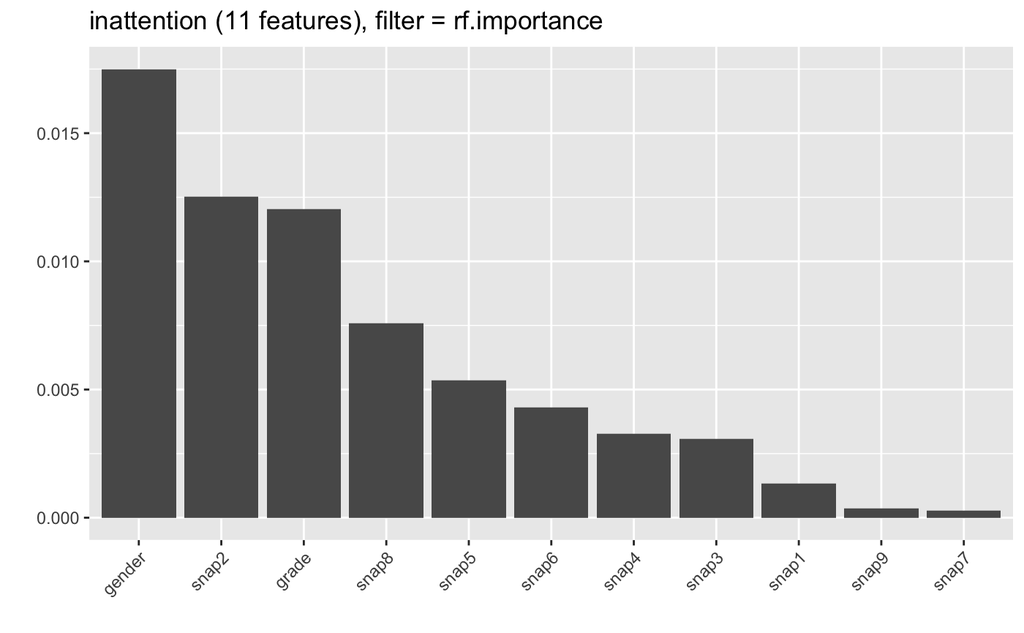

```r
# plotFilterValuesGGVIS(fv)
plotFilterValues(fv)
```

```r
getFilteredFeatures(fv)
```

[output not shown]

```r
# Create control structures for tuning
# https://rdrr.io/cran/mlr/man/TuneControl.html
# makeTuneControlGrid - Grid search. All kinds of parameter types can be handled.
#   You can either use their correct param type and resolution, or discretize them yourself by
#   always using makeDiscreteParam in the par.set passed to tuneParams.
# same.resampling.instance - Should the same resampling instance be used for all evaluations to
#   reduce variance? Default is TRUE.
# resolution - Resolution of the grid for each numeric/integer parameter in par.set.
#   For vector parameters, it is the resolution per dimension. Either pass one resolution for all
#   parameters, or a named vector. You can pass resolution = N if you want the algorithm to
#   select N tune params given upper and lower bounds to a NumericParam
#   instead of a discrete one. Default is 10.
control.grid = makeTuneControlGrid(same.resampling.instance = TRUE, resolution = 10)
# Tuning Hyperparameters
# https://mlr-org.github.io/mlr-tutorial/devel/html/tune/index.html
# Many machine learning algorithms have hyperparameters that need to be set.
# If selected by the user they can be specified as explained on the tutorial page on Learners
# -- simply pass them to makeLearner. Often suitable parameter values are not obvious and it is
# preferable to tune the hyperparameters, that is automatically identify values that lead to
# the best performance.
# We first must define a space to search when tuning our learner.
# For example, maybe we want to tune several specific values of a hyperparameter or perhaps we
# want to define a space from 10^{−10} to 10^{10} and let the optimization algorithm decide
# which points to choose. In order to define a search space, we create a ParamSet object,
# which describes the parameter space we wish to search. This is done via the function makeParamSet.
# https://www.rdocumentation.org/packages/ParamHelpers/versions/1.1-36/topics/makeParamSet?
# Multiple sets can be concatenated with c
# Create A Description Object For A Parameter, e.g.
# makeDiscreteParam(id, values, requires = NULL)
# id - Name of parameter
# values - Possible discrete values. Instead of using a vector of atomic values, you are also
#   allowed to pass a list of quite complex R objects, which are used as discrete choices.
ps = makeParamSet(
  makeDiscreteParam("cp", values = seq(0,0.4,0.1)),
  makeDiscreteParam("minsplit", values = c(10,20))
)
print(ps)
```

```
             Type len Def            Constr Req Tunable Trafo
cp       discrete   -   - 0,0.1,0.2,0.3,0.4   -    TRUE     -
minsplit discrete   -   -             10,20   -    TRUE     -
```

```r
# Hyperparameter Tuning.
# https://www.rdocumentation.org/packages/mlr/versions/2.9/topics/tuneParams?
# Optimizes the hyperparameters of a learner. Allows for different optimization methods,
# such as grid search, evolutionary strategies, iterated F-race, etc.
# You can select such an algorithm (and its settings) by passing a corresponding control object.
# tuneParams simply performs the cross-validation for every element of the cross-product and
# selects the parameter setting with the best mean performance.
# If no performance measure is specified, by default the error rate (mmce) is used.
# You can pass other measures and also a list of measures to tuneParams.
# In the latter case the first measure is optimized during tuning, the others are simply evaluated.
# If you are interested in optimizing several measures simultaneously have a look at Advanced Tuning.
# The actual tuning, with accuracy as evaluation metric
# tuneParams(learner, task, resampling, measures, par.set, control, show.info = getMlrOption("show.info"))
# learner - The learner. If you pass a string the learner will be created via makeLearner
# task - The task
# resampling - Resampling strategy to evaluate points in hyperparameter space.
#   If you pass a description, it is instantiated once at the beginning by default,
#   so all points are evaluated on the same training/test sets. If you want to change that behavior,
#   look at TuneControl
# measures - Performance measures to evaluate. The first measure, aggregated by the first
#   aggregation function is optimized, others are simply evaluated.
#   Default is the default measure for the task, see getDefaultMeasure.
# par.set - Collection of parameters and their constraints for optimization.
#   Dependent parameters with a requires field must use quote and not expression to define it.
# control -  Control object for search method. Also selects the optimization algorithm for tuning.
# show.info -  Print verbose output on console? Default is set via configureMlr
res = tuneParams(lrn, task = rpart.task, resampling = resamp, measures = list(acc,timetrain),
                 par.set = ps, control = control.grid, show.info = TRUE)
```

```
[Tune] Started tuning learner classif.rpart for parameter set:
             Type len Def            Constr Req Tunable Trafo
cp       discrete   -   - 0,0.1,0.2,0.3,0.4   -    TRUE     -
minsplit discrete   -   -             10,20   -    TRUE     -
With control class: TuneControlGrid
Imputation value: -0Imputation value: Inf
[Tune-x] 1: cp=0; minsplit=10
[Tune-y] 1: acc.test.mean=0.415,timetrain.test.mean=0.0161; time: 0.1 min; memory: 218Mb use, 627Mb max
[Tune-x] 2: cp=0.1; minsplit=10
[Tune-y] 2: acc.test.mean=0.341,timetrain.test.mean=0.0124; time: 0.0 min; memory: 218Mb use, 627Mb max
[Tune-x] 3: cp=0.2; minsplit=10
[Tune-y] 3: acc.test.mean=0.341,timetrain.test.mean=0.0118; time: 0.0 min; memory: 218Mb use, 627Mb max
[Tune-x] 4: cp=0.3; minsplit=10
[Tune-y] 4: acc.test.mean=0.341,timetrain.test.mean=0.0112; time: 0.0 min; memory: 218Mb use, 627Mb max
[Tune-x] 5: cp=0.4; minsplit=10
[Tune-y] 5: acc.test.mean=0.341,timetrain.test.mean=0.0108; time: 0.0 min; memory: 218Mb use, 627Mb max
[Tune-x] 6: cp=0; minsplit=20
[Tune-y] 6: acc.test.mean=0.425,timetrain.test.mean=0.0149; time: 0.1 min; memory: 218Mb use, 627Mb max
[Tune-x] 7: cp=0.1; minsplit=20
[Tune-y] 7: acc.test.mean=0.341,timetrain.test.mean=0.0124; time: 0.0 min; memory: 218Mb use, 627Mb max
[Tune-x] 8: cp=0.2; minsplit=20
[Tune-y] 8: acc.test.mean=0.341,timetrain.test.mean=0.0115; time: 0.0 min; memory: 218Mb use, 627Mb max
[Tune-x] 9: cp=0.3; minsplit=20
[Tune-y] 9: acc.test.mean=0.341,timetrain.test.mean=0.0112; time: 0.0 min; memory: 218Mb use, 627Mb max
[Tune-x] 10: cp=0.4; minsplit=20
[Tune-y] 10: acc.test.mean=0.341,timetrain.test.mean=0.0108; time: 0.0 min; memory: 218Mb use, 627Mb max
[Tune] Result: cp=0; minsplit=20 : acc.test.mean=0.425,timetrain.test.mean=0.0149
```

```r
print(res)
```

```
Tune result:
Op. pars: cp=0; minsplit=20
acc.test.mean=0.425,timetrain.test.mean=0.0149
```

```r
print(as.data.frame(res$opt.path))
```

| cp | minsplit | acc.test.mean | timetrain.test.mean | dob | eol | error.message | exec.time |
| --- | --- | --- | --- | --- | --- | --- | --- |
| 0 | 10 | 0.4145120 | 0.01612 | 1 | NA | NA | 2.706 |
| 0.1 | 10 | 0.3412587 | 0.01241 | 2 | NA | NA | 2.229 |
| 0.2 | 10 | 0.3412587 | 0.01180 | 3 | NA | NA | 2.159 |
| 0.3 | 10 | 0.3412587 | 0.01118 | 4 | NA | NA | 2.108 |
| 0.4 | 10 | 0.3412587 | 0.01075 | 5 | NA | NA | 2.048 |
| 0 | 20 | 0.4245713 | 0.01489 | 6 | NA | NA | 2.564 |
| 0.1 | 20 | 0.3412587 | 0.01236 | 7 | NA | NA | 2.228 |
| 0.2 | 20 | 0.3412587 | 0.01154 | 8 | NA | NA | 2.156 |
| 0.3 | 20 | 0.3412587 | 0.01119 | 9 | NA | NA | 2.106 |
| 0.4 | 20 | 0.3412587 | 0.01082 | 10 | NA | NA | 2.062 |

```r
# https://mlr-org.github.io/mlr-tutorial/devel/html/hyperpar_tuning_effects/index.html
names(res)
```

```
[1] "learner"   "control"   "x"         "y"         "threshold" "opt.path"
```

```r
print(c(res$x$cp, res$x$minsplit))
```

```
[1]  0 20
```

```r
print(res$y)
```

```
      acc.test.mean timetrain.test.mean
          0.4245713           0.0148900
```

```r
# Investigating hyperparameter tuning effects
# https://www.rdocumentation.org/packages/mlr/versions/2.9/topics/generateHyperParsEffectData?
generateHyperParsEffectData(res, include.diagnostics = TRUE)
```

```
HyperParsEffectData:
Hyperparameters: cp,minsplit
Measures: acc.test.mean,timetrain.test.mean
Optimizer: TuneControlGrid
Nested CV Used: FALSE
Snapshot of $data:
   cp minsplit acc.test.mean timetrain.test.mean iteration eol error.message exec.time
1 0.0       10     0.4145120             0.01612         1  NA          <NA>     2.706
2 0.1       10     0.3412587             0.01241         2  NA          <NA>     2.229
3 0.2       10     0.3412587             0.01180         3  NA          <NA>     2.159
4 0.3       10     0.3412587             0.01118         4  NA          <NA>     2.108
5 0.4       10     0.3412587             0.01075         5  NA          <NA>     2.048
6 0.0       20     0.4245713             0.01489         6  NA          <NA>     2.564
```

```r
# Classification
frmla = averBinned ~ gender + grade + snap1 + snap2 + snap3 +
    snap4 + snap5 + snap6 + snap7 + snap8 + snap9
fit.cla <- ctree(frmla, data=D)
print(fit.cla)
plot(fit.cla)
class(fit.cla)  # class type
#Table of prediction errors
table(predict(fit.cla), D$averBinned)
# Estimated class probabilities
tr.pred = predict(fit.cla, newdata=D, type="prob")
print(head(tr.pred))
```

[output not shown]